# Analysis of SARS-CoV2 SNPs

2024-10

## Setup

```r
snp_file <- "data/sample_snp_data.csv"
sample_id <- "SRR12433063"
```

```r
# Load required libraries and source the function
library(ggplot2)
source("code/functions/SNP_analyzation.R")
```

## Project description

In this project, we analyze a data set of single nucleotide polymorphisms to investigate genetic variation in multiple genome samples. The analysis focuses on extracting data from a specific sample, visualizing SNP quality scores, and generating different types of figures to demonstrate the results of each genome. In Figure one chromosome position is on the x and quality score is on y.“Ggplot2” (Wickham 2016) was used to execute a accurate visual box plot and scatter plot. The data in these graphs was subset from a large set of SNP samples, “dplyr”(Wickham et al. 2023) was used to manipulate the data from the original data frame. To accurately apply references and citations to support the figures “citr” (RStudio 2023) was used to cite R packages.After the “Report.Rmd” file was completed it was kitted using (Xie 2023) to configure a “Report.html” output report. Chat GPT (OpenAI 2023) was also used as a reference in code of figures.

## Subsetting data

```r
# Pass only the SNP_file and sample_id arguments
single_sample_data <- subset_snp_data(file_path = snp_file,
                                      sample_id = sample_id)
# Create a csv file for subset data
output_file <- paste0("data/subset_snp_data", sample_id, ".csv")
write.csv(single_sample_data, file = output_file, row.names = FALSE)

# Confirmation message
cat("subset file saved as:", output_file)
```

```
## subset file saved as: data/subset_snp_dataSRR12433063.csv
```

## Figures

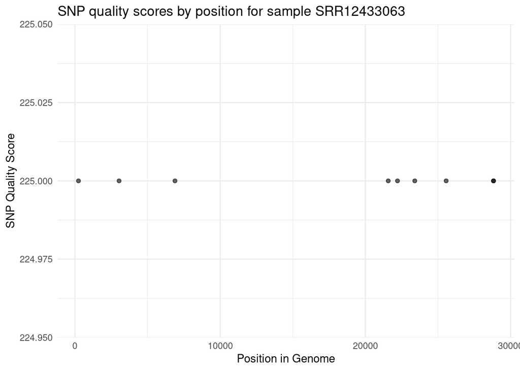

**Figure 1.** Scatterplot of SNP quality scores by genome position for sample SRR12433063. This figure shows the relationship between distribution of SNP quality scores across the genome, with each point representing a specific SNP position and its associated quality score.

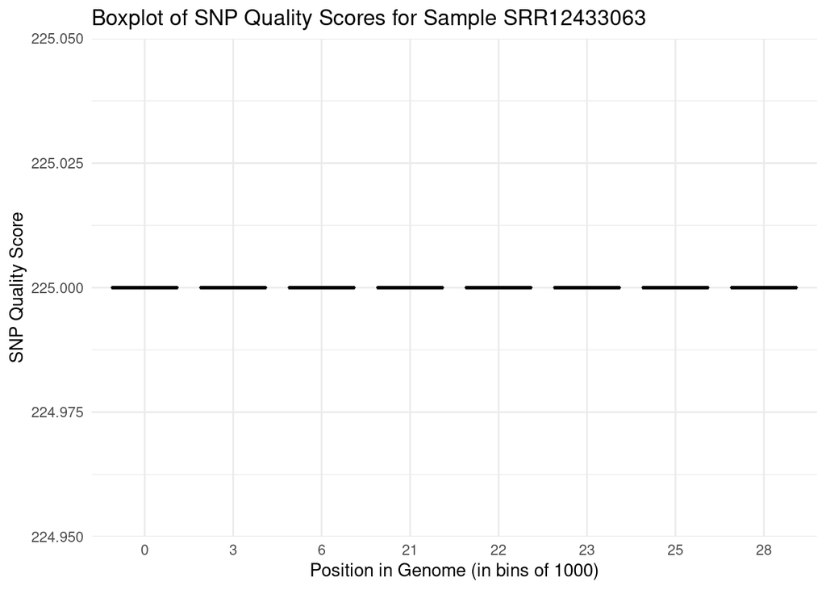

```r
# Boxplot of SNP Quality Scores by Position Category (e.g., grouped by bins)
boxplot_plot <- ggplot(single_sample_data, aes(x = factor(pos %/% 1000),
                                               y = qual)) +
  geom_boxplot(fill = "skyblue", color = "black", outlier.colour = "red",
               outlier.shape = 16) +
  labs(
    title = paste("Boxplot of SNP Quality Scores for Sample", sample_id),
    x = "Position in Genome (in bins of 1000)",
    y = "SNP Quality Score"
  ) +
  theme_minimal()

# Save the box plot to a PNG file
ggsave(filename = paste0("output/box_plot_", sample_id, ".png"),
       plot = boxplot_plot, width = 8, height = 6)

# Display the boxplot
boxplot_plot
```

[session information not shown]

## Sources Cited

```
# Sources cited
```

OpenAI. 2023. *ChatGPT: OpenAI’s Language Model for Generating Human-Like Text*.

RStudio. 2023. *Citr: RStudio Add-in to Insert Markdown Citations*. https://CRAN.R-project.org/package=citr.

Wickham, Hadley. 2016. *Ggplot2: Elegant Graphics for Data Analysis*. Springer-Verlag New York. https://ggplot2.tidyverse.org.

Wickham, Hadley, Romain François, Lionel Henry, Kirill Müller, and Davis Vaughan. 2023. *Dplyr: A Grammar of Data Manipulation*. https://CRAN.R-project.org/package=dplyr.

Xie, Yihui. 2023. *Knitr: A General-Purpose Package for Dynamic Report Generation in R*. https://yihui.org/knitr/.